# LeagueDataProject

#### Game Length By Different Leagues

I can compare the length of games by leagues, from this data I can start to figure out what league is the most efficient at closing out games.

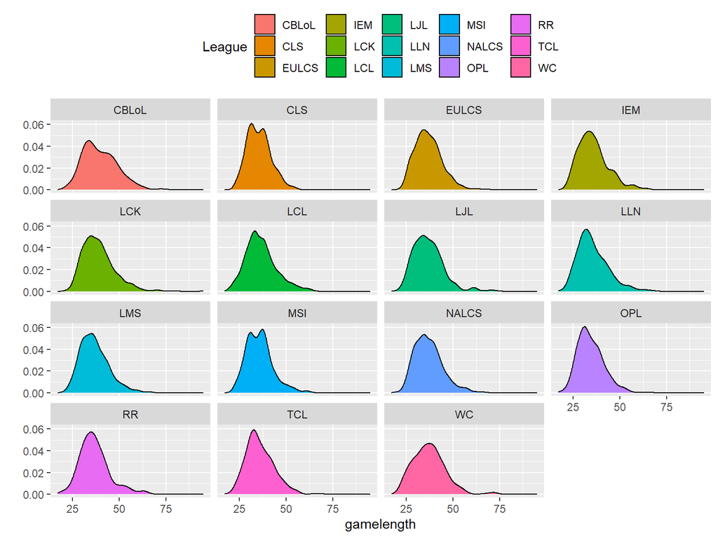

# Wins of Blue Side vs Red

Let’s compare to see if maybe one side has more landscape advantages. Now we can that blue side has more wins but why?

```
##      n
## 1 4146
```

```
##      n
## 1 3474
```

##### What team has the best record?

We can see here from count that the Blue side has won more than the red side but lets figure out what teams perform the best on either side

```
## # A tibble: 216 x 3
## # Groups:   blueTeamTag, bResult [216]
##    blueTeamTag bResult     n
##    <chr>         <int> <int>
##  1 SKT               1   146
##  2 TSM               1   104
##  3 kt                1   101
##  4 SSG               1    99
##  5 FNC               1    97
##  6 H2K               1    95
##  7 CLG               1    92
##  8 C9                1    90
##  9 FW                1    88
## 10 ROX               1    80
## # ... with 206 more rows
```

Get both sides blue and red to see what team has the best record.

```
## # A tibble: 205 x 3
## # Groups:   redTeamTag, rResult [205]
##    redTeamTag rResult     n
##    <chr>        <int> <int>
##  1 SKT              1   141
##  2 TSM              1   103
##  3 C9               1    88
##  4 kt               1    85
##  5 SSG              1    82
##  6 FW               1    77
##  7 CLG              1    73
##  8 G2               1    70
##  9 ahq              1    68
## 10 UOL              1    68
## # ... with 195 more rows
```

The team SKT is a very successful team from Korea and are definitely considered one of the best teams in the world due to their repeated appearances in the World Cup Championships and 3 titles under their belt, which is the most out of any team.

### Team With the worst record?

```
## # A tibble: 238 x 3
## # Groups:   redTeamTag, rResult [238]
##    redTeamTag rResult     n
##    <chr>        <int> <int>
##  1 JAG              0    86
##  2 TL               0    80
##  3 NV               0    79
##  4 SSG              0    73
##  5 ROX              0    71
##  6 UOL              0    71
##  7 TSM              0    69
##  8 CLG              0    68
##  9 SKT              0    67
## 10 FNC              0    65
## # ... with 228 more rows
```

```
## # A tibble: 233 x 3
## # Groups:   blueTeamTag, bResult [233]
##    blueTeamTag bResult     n
##    <chr>         <int> <int>
##  1 SSG               0    68
##  2 JAG               0    64
##  3 C9                0    63
##  4 CLG               0    62
##  5 kt                0    62
##  6 GIA               0    59
##  7 NV                0    58
##  8 ROX               0    57
##  9 TL                0    57
## 10 UOL               0    57
## # ... with 223 more rows
```

I also realized technically that the team has the worst record isn’t as accurate because of the sample size not being the same since they didn’t play the same amount of games. Yet we can still see that SKT is well above everybody and they’ve played the most games and not another team from that league can keep up with them.

### Ban Phase

So before every game starts before a professional competitive match, a ban phase occurs. Where a team can ban a champion before they can pick them because they know that a player on the opposing team is very good with. So that’s where pro players must have a large champion pool so they can be good enough to help their team win.

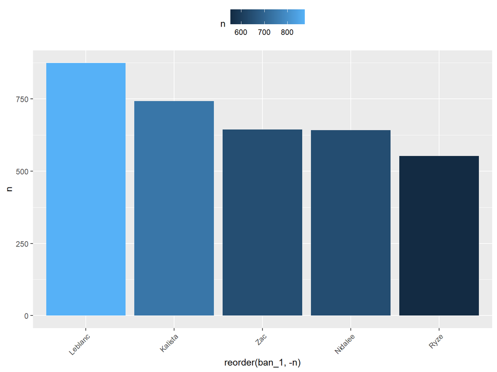

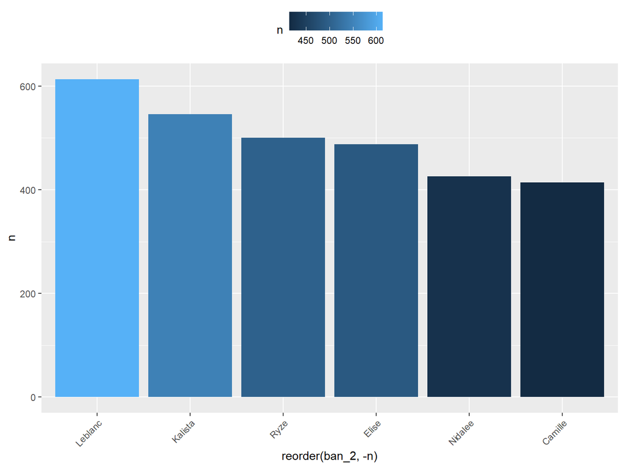

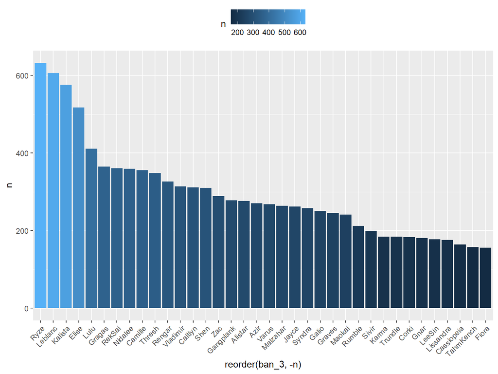

### Patch 7.11

Around 2017ish, Riot decided to give each team 2 more bans which in total created 5. Which allowed for more strategic ban phases and more flexibility as where both teams are forced to choose 3 people before banning the last two champions. This decision allowed for more fair chances at eliminating champions that were not chosen yet due to their designated role.

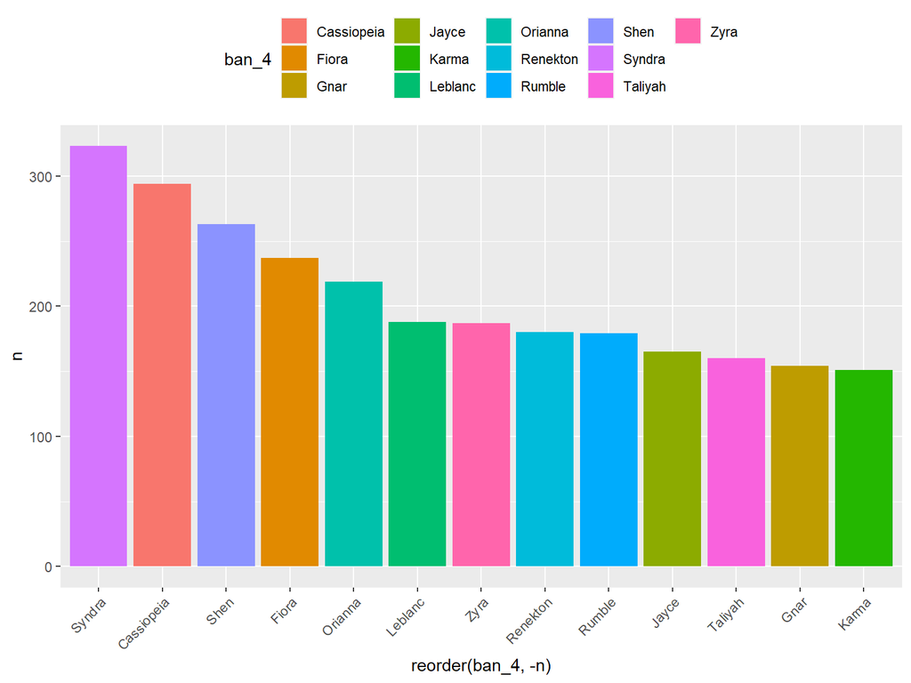

### Ban 5

We start to realize and notice that these 2 more bans have really ruled out midlaners.

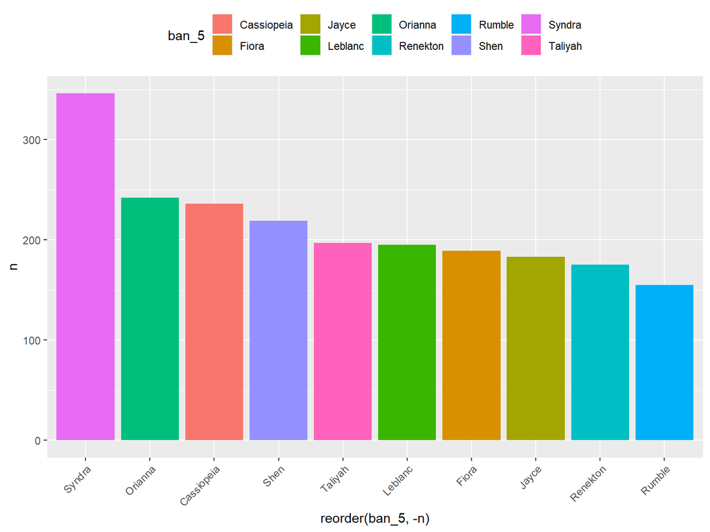

# Downfall

In 2015 and 2016, SKT1 has been the only team in all of tournament history to ever achieve a back to back championship world title. Unfortunately in 2017, their run had been stopped short by Samsung White due to them banning a lot of faker’s champion pool.

```
##   Year blueMiddle blueMiddleChamp          Type bResult League
## 1 2017      Faker      Cassiopeia International       1     WC
## 2 2017      Faker            Fizz International       1     WC
## 3 2017      Faker         Orianna International       1     WC
## 4 2017      Faker           Galio International       1     WC
## 5 2017      Faker         Taliyah International       0     WC
## 6 2017      Faker         Taliyah International       1     WC
## 7 2017      Faker           Galio International       1     WC
## 8 2017      Faker           Galio International       1     WC
```

```
##    Year redMiddle redMiddleChamp          Type rResult League
## 1  2017     Faker        Orianna International       1     WC
## 2  2017     Faker       Kassadin International       0     WC
## 3  2017     Faker           Fizz International       1     WC
## 4  2017     Faker          Corki International       0     WC
## 5  2017     Faker           Ryze International       1     WC
## 6  2017     Faker          Galio International       0     WC
## 7  2017     Faker          Galio International       0     WC
## 8  2017     Faker          Galio International       1     WC
## 9  2017     Faker     Cassiopeia International       0     WC
## 10 2017     Faker           Ryze International       0     WC
## 11 2017     Faker          Karma International       0     WC
```

### Gold Differences Graphs

At the end of every match, there is actually a built in graph that I was trying to model after which shows the gold difference between both teams, and you can see when the game has turned around or not/at a certain point you can. At midpoint through the game, predictions can be made on which team is more fit to win the match. I had to use a data frame so I can iterate through all of the rows that had gold values throughout each minute of the game. The game_id is just the row number of the gold data set so you can access any game and see the gold graph visualized.

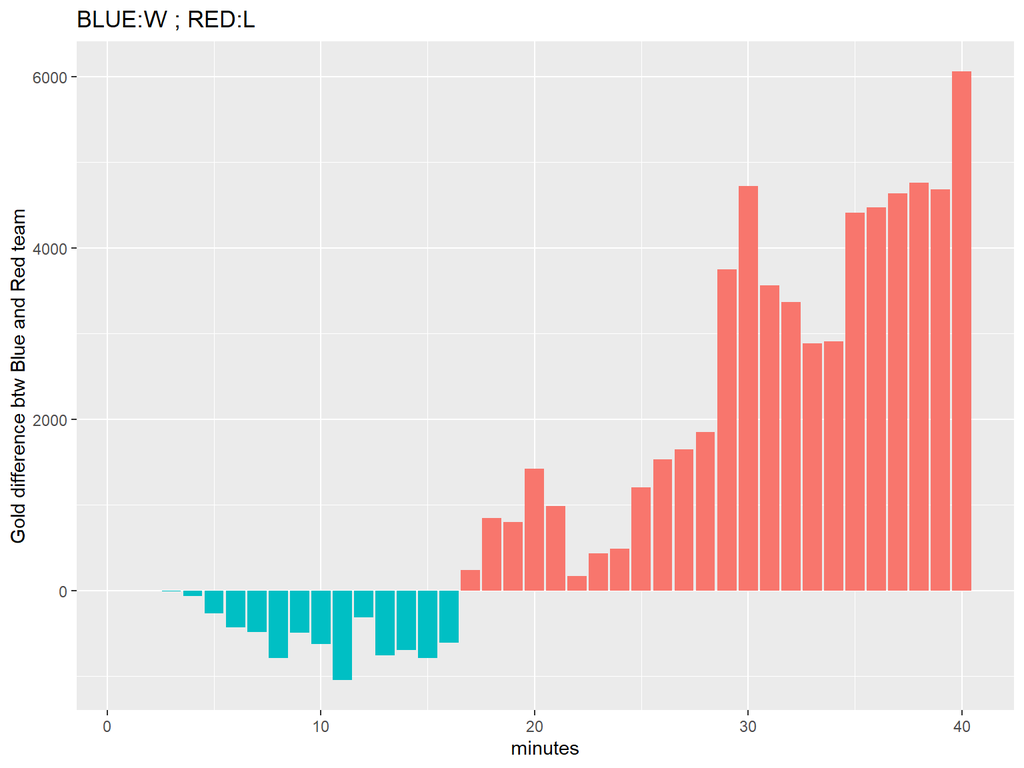

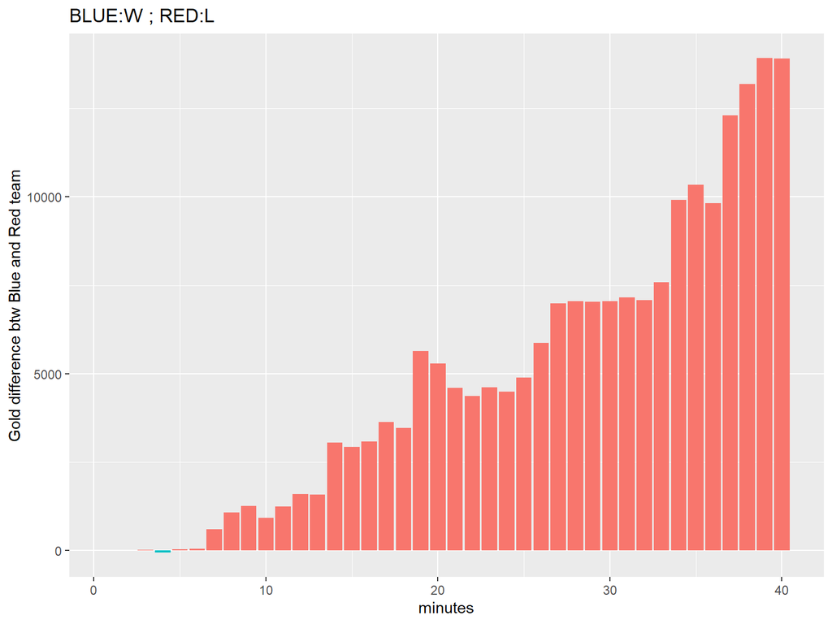

# Fnatic’s Perfect Season

The reason why I used Fnatic’s perfect season was because this is the only time in LCS did they win, but they had an abundant amount of games and as well as I can see the different objectives that helped win their games, and see which the most impactful one. As well as to see the correlation using a heatmap.

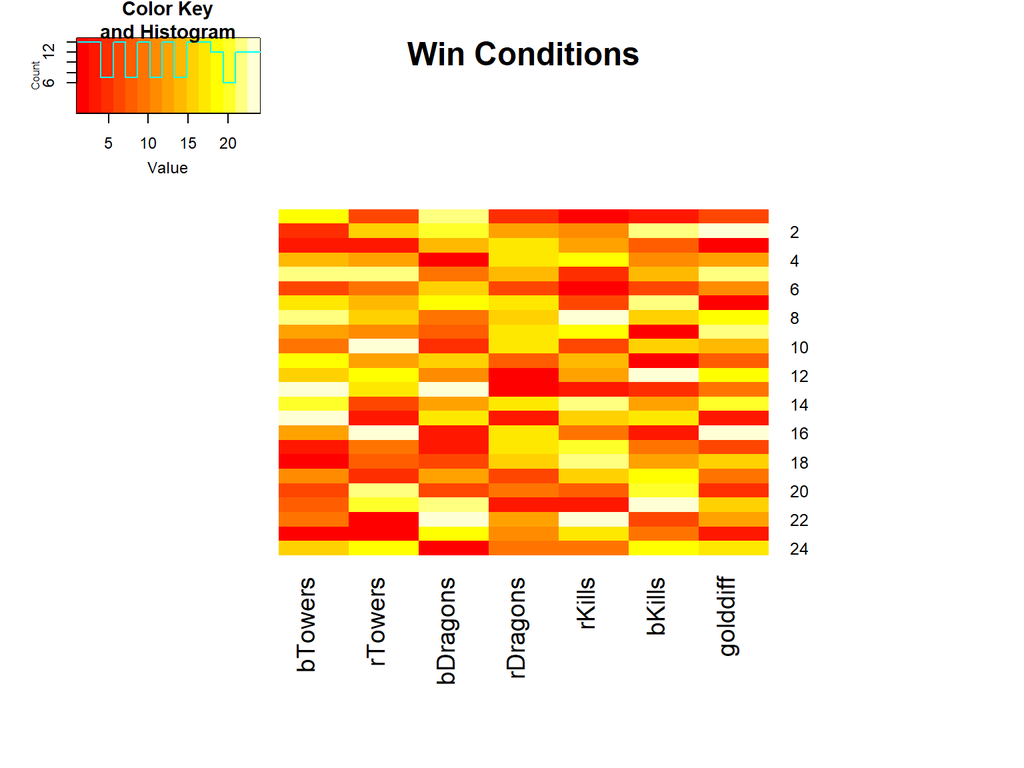

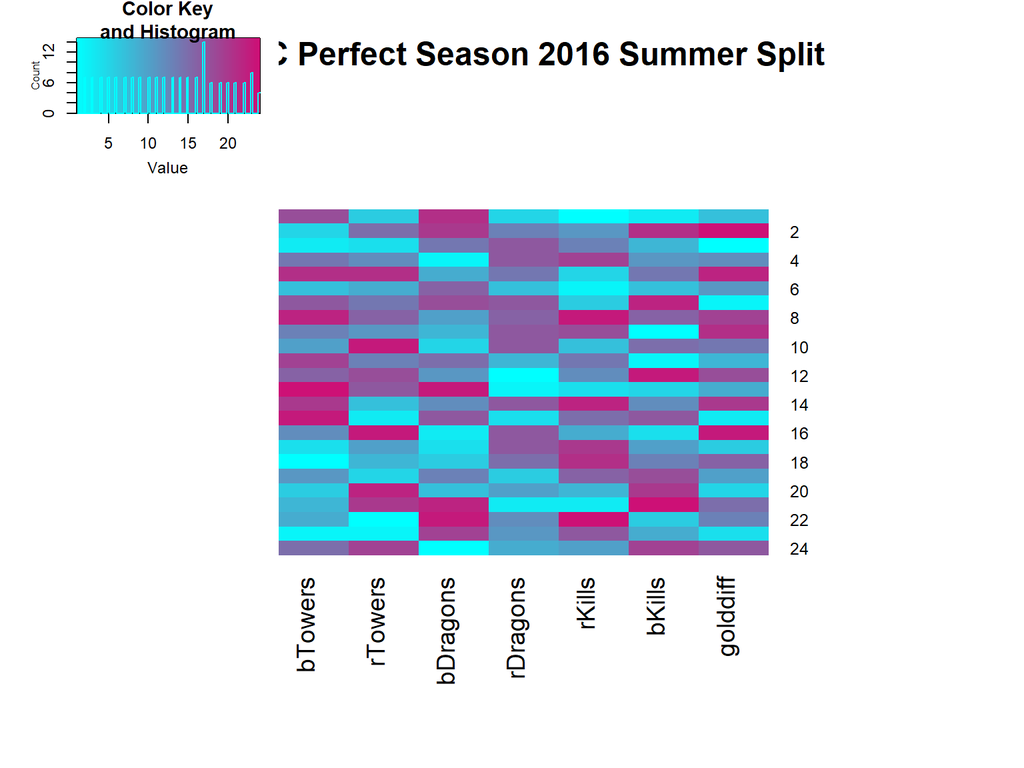

# SKT’s Championship Game

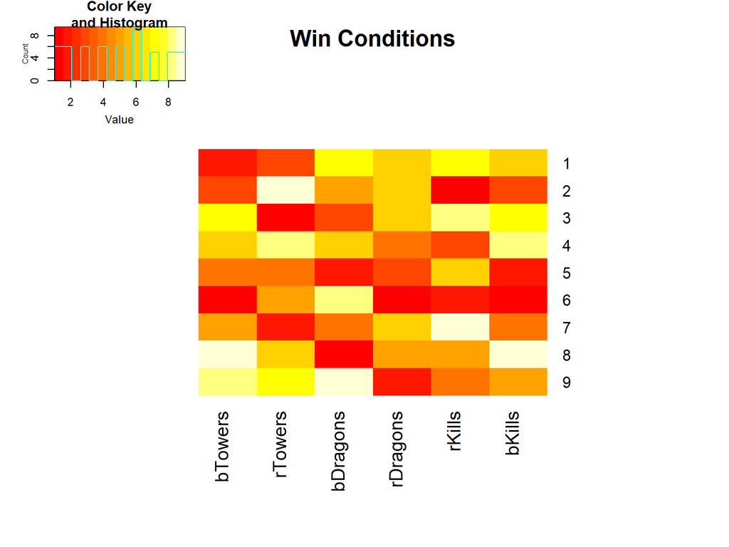

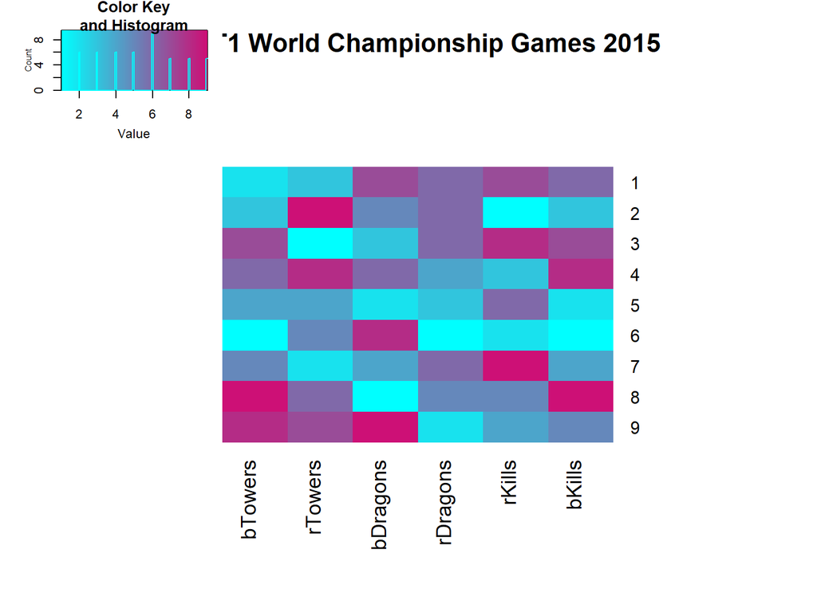

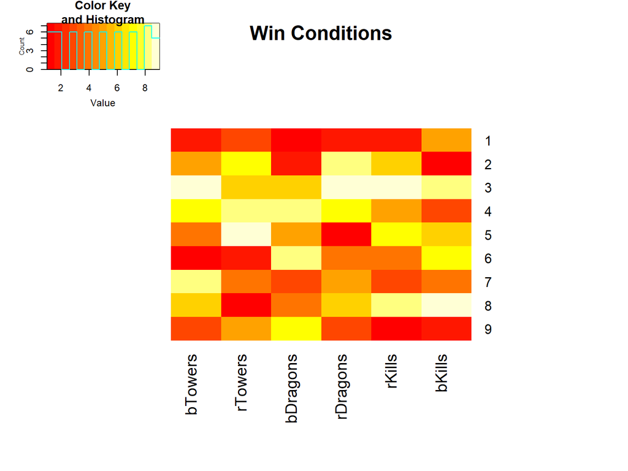

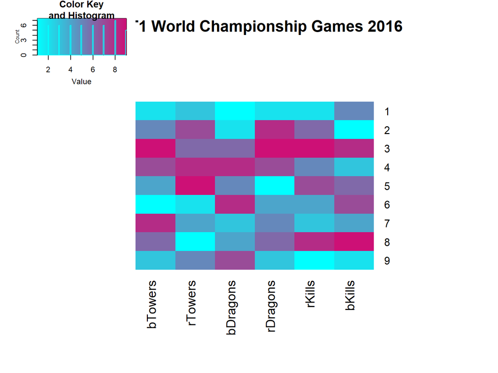